# Progress Memo 2

Final Project  
Data Science 1 with R (STAT 301-1)

Author

Sarah Norman

Published

November 19, 2024

**Github Repo Link**

[Sarah’s Repo Link](https://github.com/stat301-1-2024-fall/final-project-1-sarahdnor.git)

**Data Source**

Link:

[Skincare and Technology Survey Among Malaysians](https://www.kaggle.com/datasets/nurunnz/skincare-survey-among-malaysian-2021?resource=download)

APA Citation:

Nurunnajwa, Harith Hakim, and Azri Hadif. (2022). Skincare and Technology Survey Among Malaysian [Data set]. Kaggle. https://doi.org/10.34740/KAGGLE/DSV/3371747

## About the data:

The Skincare Survey in Malaysia 2021 CSV dataset was collected by Nurunnajwa, Harith Hakim, and Azri Hadif, all of whom were students at Universiti Teknologi Malaysia at the time of data collection. I accessed this data on 10/31/2024 from Kaggle. The Temporal Coverage Start Date (when data collection began) was 11/30/2021, and the Temporal Coverage End Date (when data collection ended) was 12/30/2022. The specific report referenced in this memo does not have a published date; however, it appears that viewers have been downloading the dataset since October 2007, and the overall report was last updated three years ago. As stated in the report, “the goal of this data collection is to know the skin problems among Malaysians and the suitability of AI Face Scanners to track skin issues as a quick fix.”

## Why this data

Given my major in International Studies, I take every opportunity to explore different countries of interest. Being born in Malaysia, I started examining datasets on Malaysia. I found this particular dataset intriguing due to its unusual specificity. I also I recall cosmetic surgery being a common topic of conversation among my peers when I was in the Philippines attending an international school. I was also drawn to the dataset’s mention of AI, given its current prominence. I find it even more intriguing given that the dataset is quite old, prior to the surge in AI usage. This could provide an opportunity to further explore how AI technology has evolved. There is also an opportunity to discuss the disparities in perceptions of skincare between Western and Asian countries. As a young woman, I resonate with the challenges surrounding appearance and am eager to understand more about its impact on Southeast Asian culture. Additionally, I appreciate the variety of variables in this dataset, which offer a chance to experiment with both numbers and strings, further developing my skills.

## Data quality & complexity check

Table 1: Summary of Data

Data summary

| Name | skincare_malaysia |
| --- | --- |
| Number of rows | 76 |
| Number of columns | 31 |
| _______________________ |  |
| Column type frequency: |  |
| character | 17 |
| numeric | 14 |
| ________________________ |  |
| Group variables | None |

**Variable type: character**

| skim_variable | n_missing | complete_rate | min | max | empty | n_unique | whitespace |
| --- | --- | --- | --- | --- | --- | --- | --- |
| Timestamp | 0 | 1.00 | 27 | 28 | 0 | 76 | 0 |
| Gender | 0 | 1.00 | 4 | 6 | 0 | 2 | 0 |
| Age | 1 | 0.99 | 4 | 5 | 0 | 5 | 0 |
| Race | 0 | 1.00 | 4 | 23 | 0 | 15 | 0 |
| Occupation | 0 | 1.00 | 3 | 10 | 0 | 5 | 0 |
| Have you ever used any skin care products? | 0 | 1.00 | 2 | 3 | 0 | 2 | 0 |
| Which, if any, of the following statements applies to you? | 0 | 1.00 | 16 | 189 | 0 | 54 | 0 |
| Which of the following types of ingredients would make you more likely to buy a skin care product? | 0 | 1.00 | 19 | 184 | 0 | 26 | 0 |
| How do/did you choose your products? | 0 | 1.00 | 5 | 174 | 0 | 42 | 0 |
| Do you use samples before buying skincare products? | 0 | 1.00 | 2 | 3 | 0 | 2 | 0 |
| How often do you buy skincare products? | 0 | 1.00 | 5 | 10 | 0 | 5 | 0 |
| Where do you purchase your skin care products? | 0 | 1.00 | 8 | 75 | 0 | 15 | 0 |
| On average, how much do you spend on skincare products each month? | 0 | 1.00 | 8 | 15 | 0 | 5 | 0 |
| Do you think that technology can improve your skincare routine? | 0 | 1.00 | 2 | 3 | 0 | 2 | 0 |
| Do you have heard about AI (Artificial Intelligent)? | 0 | 1.00 | 2 | 3 | 0 | 2 | 0 |
| After you know about AI, do you want to have a skin scanning app that can customize skincare regime? | 0 | 1.00 | 2 | 3 | 0 | 2 | 0 |
| Do share your skincare goals and motivation with us! | 18 | 0.76 | 1 | 623 | 0 | 56 | 0 |

**Variable type: numeric**

| skim_variable | n_missing | complete_rate | mean | sd | p0 | p25 | p50 | p75 | p100 |
| --- | --- | --- | --- | --- | --- | --- | --- | --- | --- |
| Do you agree that skincare is important ? | 0 | 1 | 4.43 | 0.72 | 2 | 4 | 5.0 | 5 | 5 |
| How willing are you to try different skin care products? | 0 | 1 | 3.17 | 0.96 | 1 | 3 | 3.0 | 4 | 5 |
| I wasting to much time to find out skincare and routine that suits my skin. | 0 | 1 | 3.09 | 1.15 | 1 | 2 | 3.0 | 4 | 5 |
| I being doubtful about the information shared by influencers and brand promoted content. | 0 | 1 | 3.86 | 0.98 | 1 | 3 | 4.0 | 5 | 5 |
| I feel difficult to understand the list of ingredients on the products. | 0 | 1 | 3.42 | 1.12 | 1 | 3 | 3.5 | 4 | 5 |
| I bought expensive product but doesn’t see any improvement on my skin. | 0 | 1 | 3.17 | 1.20 | 1 | 2 | 3.0 | 4 | 5 |
| I unaware of which ingredients is the best or to avoid according my skin type. | 0 | 1 | 3.39 | 1.12 | 1 | 3 | 4.0 | 4 | 5 |
| I experienced allergies after use a new skincare products ( Eg : Rashness, acne, purging etc) | 0 | 1 | 2.95 | 1.37 | 1 | 2 | 3.0 | 4 | 5 |
| I want to reduce time to find which routine / products suits with my skin. | 0 | 1 | 4.03 | 0.95 | 1 | 3 | 4.0 | 5 | 5 |
| I want have solutions from expert in effortless and cheap way. | 0 | 1 | 4.18 | 1.04 | 1 | 4 | 4.5 | 5 | 5 |
| I want to have my personalized skincare routine that suitable with my current products. | 0 | 1 | 4.17 | 1.04 | 1 | 4 | 4.0 | 5 | 5 |
| I want to gain knowledge of skincare regime in easy and understandable way. | 0 | 1 | 4.41 | 0.79 | 2 | 4 | 5.0 | 5 | 5 |
| I want to adapt a healthy lifestyle for a glowing and healthy skin. | 0 | 1 | 4.54 | 0.70 | 2 | 4 | 5.0 | 5 | 5 |
| Do you feel excited to use this skincare application? | 0 | 1 | 4.09 | 1.05 | 1 | 4 | 4.0 | 5 | 5 |

As seen in Table 1 the dataset has a total of 31 variables with a variety of both character and numerical variable types (17 and 14, respectively). The observations for the dataset, however, can be considered quite small, with the dataset having only 76 observations. However, I personally appreciate this dataset’s size because I feel it represents a more realistic sample size for a survey that might be conducted on campus.

Table 2: Count of Different Occupations Surveyed

| Occupation | n |
| --- | --- |
| Consultant | 1 |
| Employee | 11 |
| Own | 1 |
| Retired | 3 |
| Student | 60 |

Table 3: Distribution of Gender

| Gender | n |
| --- | --- |
| Female | 58 |
| Male | 18 |

The vast majority of the sample are university students (with 60 of the 76 observations being from students) and females (with 58 of the observations being female and 18 being male) which can be seen in Table 2 and Table 3.

This may lend the dataset to bias, given that its purpose is to better understand skin problems/perceptions and the use of AI face scanners across the country.

Table 4: Distribution of ‘Race’

| Race |
| --- |
| Malay |
| korean |
| Chinese |
| Libya |
| Bumiputra sabah |
| Indian |
| Bumiputra Sabah (Bajau) |
| African |
| Arabian |
| Sudanese |
| JAVANESSE |
| Arab |
| sabahan |
| Iban |
| Nigerian |

It is also important to note that there is more than just one distinct race/nationality represented in the data set, despite the study claiming to explore the perceptions of specifically Malaysians. The report also claims that the geospatial coverage of the survey is “worldwide”. This conflicting information will be further explored in the misc section of this memo.

However, The data does not experience significant missingness issues, only encountering missing values for age and the question “Do share your skincare goals and motivation with us!”

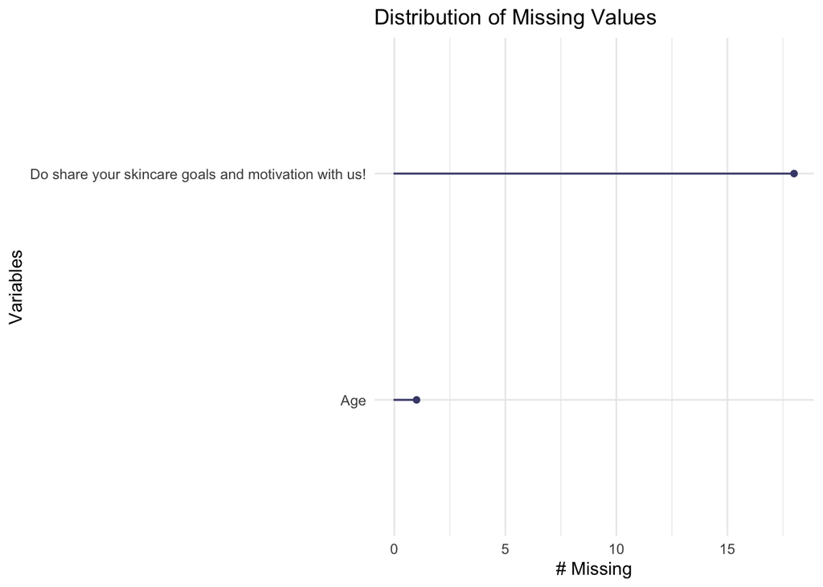

Figure 1

The final comments question (“Do share your skincare goals and motivation with us!”) has a total of 18 missing values, while the age variable has 1 missing value (not posing great issues for the dataset) as seen in Figure 1. Given that the final comments question has relatively significant missingness, it can be inferred that it was an optional question.

The data appears to be relatively tidy. However, the column titles do not following the snake_case naming convention. Column names include capital letters and spaces but are also quite lengthy. Name cleaning and rewriting of column names (a combination of both the clean_names() function from the janitor package and string functions) will likely need to be done for clarity and aesthetics.

## Potential data issues

The last column of this dataset, alongside the multiple-choice answer questions (e.g., “Which, if any, of the following statements applies to you?”), is part of what drew me to this dataset, as they pose new challenges that I have yet to face in the course. However, I have yet to work with cells containing multiple values. Additionally, the final column, given that it consists of unique strings (individual written responses), will be difficult to examine but will provide interesting insights about perceptions of skincare and individual motivations. Some cleaning will also have to be done regarding some variable names such as the variables present under the “races” column shown above- perhaps some of this data can be changed into a factor data type. The term “race” also needs to be established, or perhaps the column name should be changed for greater accuracy.

## Misc

There are some point of confusion in the dataset:

The description and written components of the data contain various grammatical errors and conflicting points. This may indicate that the text was translated and could lead to challenges during the EDA. Despite these issues, the text remains understandable but appears less professional and organized.

There seems to be conflicting information regarding the demographics of the study. For example, the dataset claims to have worldwide geospatial coverage but has proportionally few responses from respondents of different races/nationalities. Additionally, there is some confusion about which age groups are targeted for the study, as the description discusses general Malaysian culture but also emphasises women and teenagers. The survey also seems to have been conducted in a university setting based on occupational observations.

Although this poses some confusion, as long as these components are clarified in the EDA, I don’t believe they will create issues during analysis, as the values in the dataset are relatively clear and can always be manipulated.

Upon initial review of the data, some interesting areas for exploration include distinguishing differences across gender (acknowledging that there are more females than males represented in the dataset). It will also be interesting to extract similarities within the responses for the final questions, “Which, if any, of the following statements applies to you?” and “Do share your skincare goals and motivation with us!”, especially since the final question is open-ended. I think there are a handful of different relationships that can be mapped.

## Tidying Data

As mentioned previously, this dataset requires tidying prior to exploratory data analysis (EDA). However, upon further investigation, extensive cleaning was needed in addition to the creation of a codebook.

The following steps were taken to tidy the data:

All columns have been renamed to follow the snake_case naming convention and revised for clarity, as many of the variable titles were excessively long and contained grammatical errors. This required each column to be renamed individually. In addition to cleaning names, variables were converted to lowercase (except for binary yes or no values). The newly named cultural_identity, occupation, gender, purchase_frequency, skincare_spending, and skincare_experience columns were converted to factors for ease and clarity of analysis. The skincare_spending variable had its factor levels reordered chronologically to make the data analysis more intuitive. Cultural_identity was modified to ensure that respondents who provided the same value with slight variations, such as differences in capitalization or acronyms, were grouped under the same factor variable.

Table 5: Variable Name Comparison

| New Names | Original Names |
| --- | --- |
| timestamp | Timestamp |
| gender | Gender |
| age | Age |
| cultural_identity | Race |
| occupation | Occupation |
| skincare_importance | Do you agree that skincare is important ? |
| skincare_experience | Have you ever used any skin care products? |
| skin_type | Which, if any, of the following statements applies to you? |
| perceptions_of_ingredients | Which of the following types of ingredients would make you more likely to buy a skin care product? |
| product_choice_process | How do/did you choose your products? |
| use_of_samples | Do you use samples before buying skincare products? |
| purchase_frequency | How often do you buy skincare products? |
| trying_new_skincare | How willing are you to try different skin care products? |
| where_purchased | Where do you purchase your skin care products? |
| skincare_spending | On average, how much do you spend on skincare products each month? |
| time_spent_finding_routine | I wasting to much time to find out skincare and routine that suits my skin. |
| doubts_skincare_media | I being doubtful about the information shared by influencers and brand promoted content. |
| understanding_of_products | I feel difficult to understand the list of ingredients on the products. |
| product_no_improvement | I bought expensive product but doesn’t see any improvement on my skin. |
| unaware_ingredient_quality | I unaware of which ingredients is the best or to avoid according my skin type. |
| experienced_allergies | I experienced allergies after use a new skincare products ( Eg : Rashness, acne, purging etc) |
| desire_skincare_efficiency | I want to reduce time to find which routine / products suits with my skin. |
| want_solutions | I want have solutions from expert in effortless and cheap way. |
| desire_for_routine | I want to have my personalized skincare routine that suitable with my current products. |
| desire_know_more | I want to gain knowledge of skincare regime in easy and understandable way. |
| desire_better_lifestyle | I want to adapt a healthy lifestyle for a glowing and healthy skin. |
| perceptions_of_technology | Do you think that technology can improve your skincare routine? |
| heard_of_ai | Do you have heard about AI (Artificial Intelligent)? |
| perceptions_skin_scanning | After you know about AI, do you want to have a skin scanning app that can customize skincare regime? |
| excitment_skincare_ai | Do you feel excited to use this skincare application? |
| motivations | Do share your skincare goals and motivation with us! |

Table 5 shows a side-by-side comparison of the newly created names and the dataset’s original names, highlighting the now clearer and more concise names following correct naming conventions.

Table 6: Skincare Malaysia Codebook

[output not shown]

The original dataset lacked a codebook, necessitating the creation of the codebook shown in Table 6. Concerns arose due to the absence of a description for the ranking scale. As a result, the values represented by 1 to 5 had to be inferred. This was achieved by examining the first variable with this numeric ranking, skincare_importance, and deducing that most individuals considered skincare to be important. Since 5 was more predominant than 1, it was determined that 5 indicated skincare was very important, while 1 indicated that skincare was not important. This pattern was then used to infer the rankings for the other variables. While not ideal, thorough analysis can still be conducted.

## Distribution of respondent characteristics

The following section will engage in a univariate analysis of respondent characteristics to provide greater insight into the sample. This analysis will include exploring the distributions of cultural identity, occupation, age and gender.

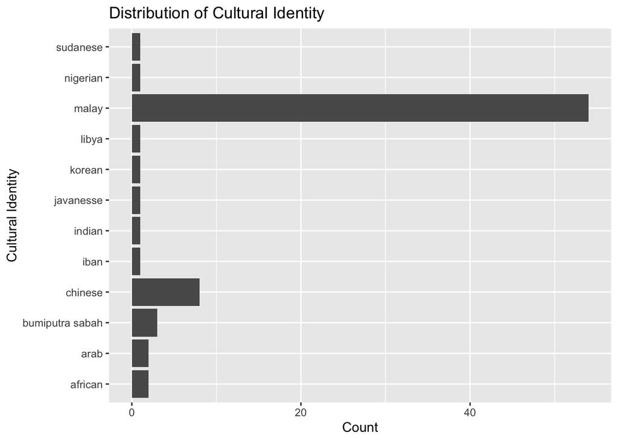

Figure 2

This specific title was chosen because “race” was not applicable, as it incorrectly categorized the values. Similarly, “ethnicity” was not a suitable descriptor, as some terms, such as Bumiputra Sabah and Bajau, are regional or legal classifications in Malaysia rather than purely ethnic groups. Additionally, terms like Libya and African denote nationalities or continents, which are not ethnicities. As a result, this variable is titled cultural identity, which is broad but still captures the diversity of the sample.

From Figure 2, we can see that there is a significant number of Malaysians (both those who identified as Malay and Bumiputra Sabah). This makes sense, given that the survey was conducted in Malaysia. However, we can still observe that a significant portion of respondents are not Malaysian.

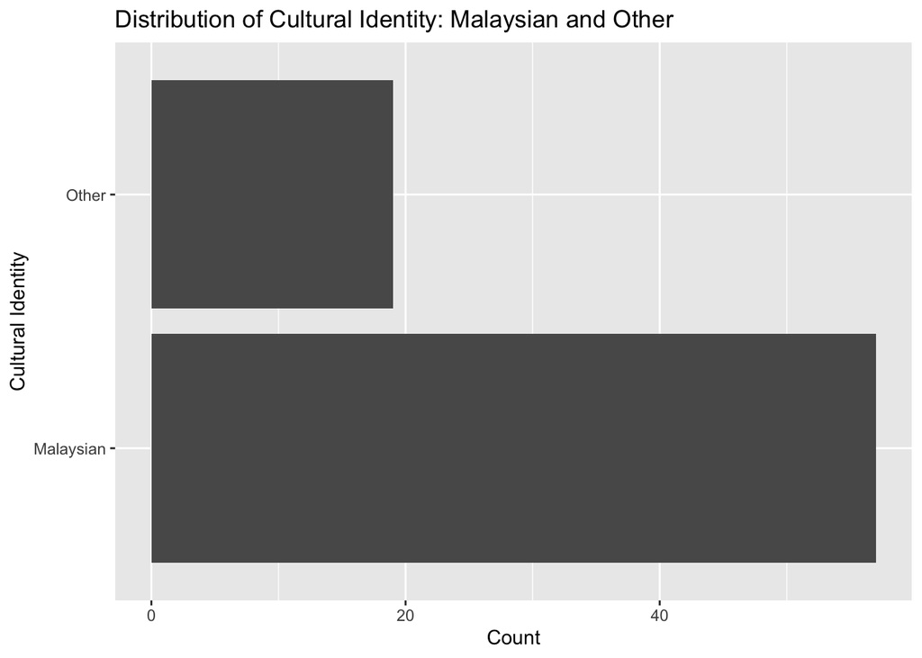

Figure 3

We can see the distribution of Malaysians to other cultural identities more clearly in Figure 3. In the above graph, Sabahans were included under Malaysians so that we can more clearly see the distribution of those who are Malaysian and those who are not.

A predominantly Malaysian sample implies that the data generally reflects Malaysian cultural norms, behaviors, and perceptions. Analysis may therefore prove valuable in the context of Malaysia.

However, the large proportion of Malaysians may also lead to skewed results that don’t accurately reflect other groups with differing cultural identities, as their skincare behaviors, cultural norms, and perceptions may vary due to this attribute. The findings, therefore, may not capture the diversity of skincare behaviors and perceptions. This may limit the applicability of the findings to broader or different cultural groups.

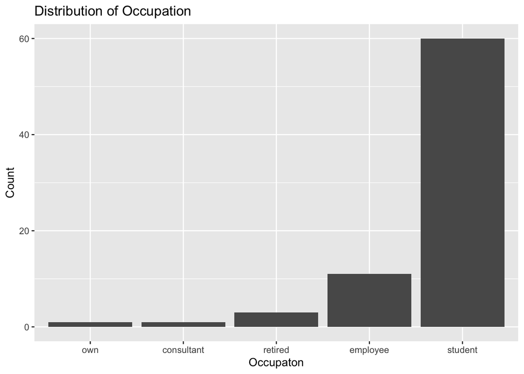

Figure 4

Figure 4 displays the distribution of occupations among respondents. From the graph, we can see that the majority of respondents are students.

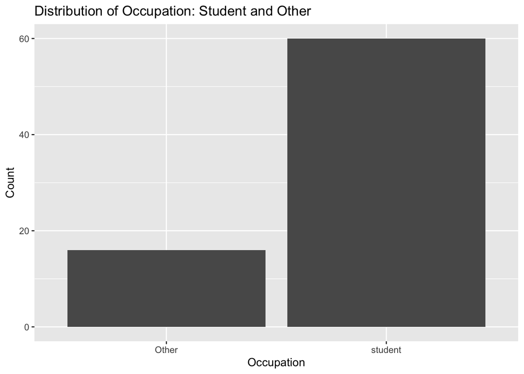

Figure 5

Figure 5 more clearly shows the distribution of students compared to those with other occupations, indicating that there are significantly more students than any other occupation. This makes sense given that the data was collected by students from Universiti Teknologi Malaysia. This once again highlights how findings may be limited to a specific demographic of Malaysians (Malaysian students) and may be less generalizable to individuals in other occupations.

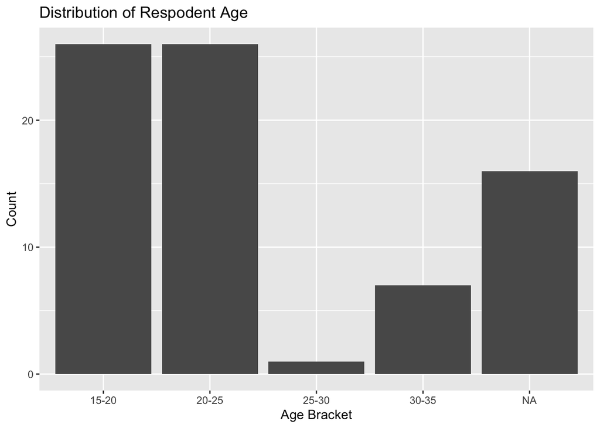

Figure 6

Figure 6 shows the distribution of age amongst respondents, broken up into 5-year age brackets. We can see that ages between 15 to 20 and 20 to 25 are the most prominent. This makes sense given that the vast majority of respondents are university students. However, it would have been useful to have the raw age of respondents, as there is a significant difference between individuals who are 15 and those who are 20, especially since the teenage years can be very formative, particularly with regard to puberty. This data supports previous analysis that the majority of respondents are younger students; however, given the large brackets for age, individual analysis of age may not be very informative.

Table 7: Proportion of Gender

| gender | count | proportion |
| --- | --- | --- |
| female | 58 | 0.7631579 |
| male | 18 | 0.2368421 |

Finally, Table 7 displays the proportion of male to female respondents from the survey, showing that there were significantly more females than males who completed it.

From this distribution analysis, we can gain a better understanding of the demographic makeup in this dataset, allowing us to draw more accurate assumptions and conclusions.

## Data broken up by gender

The following section will focus on multivariate analysis to explore the disparities between female and male respondents. This analysis is driven by stereotypes about the attitudes of women and men regarding appearance, such as the belief that women care more about their appearance and that men are less hygienic. The purpose of this analysis is to test these stereotypes.

The below table displays the proportion of males and females that have experience using skincare.

Table 8: Proportion of Females and Males with Skincare Experience

| gender | prop_skincare_experience_yes |
| --- | --- |
| female | 1.0000000 |
| male | 0.8333333 |

The Table 8 indicates that men have less experience using skincare compared to women. However, it is important to note that, as shown in Table 7, fewer males are represented in the survey, which may make the results less accurate for this demographic.

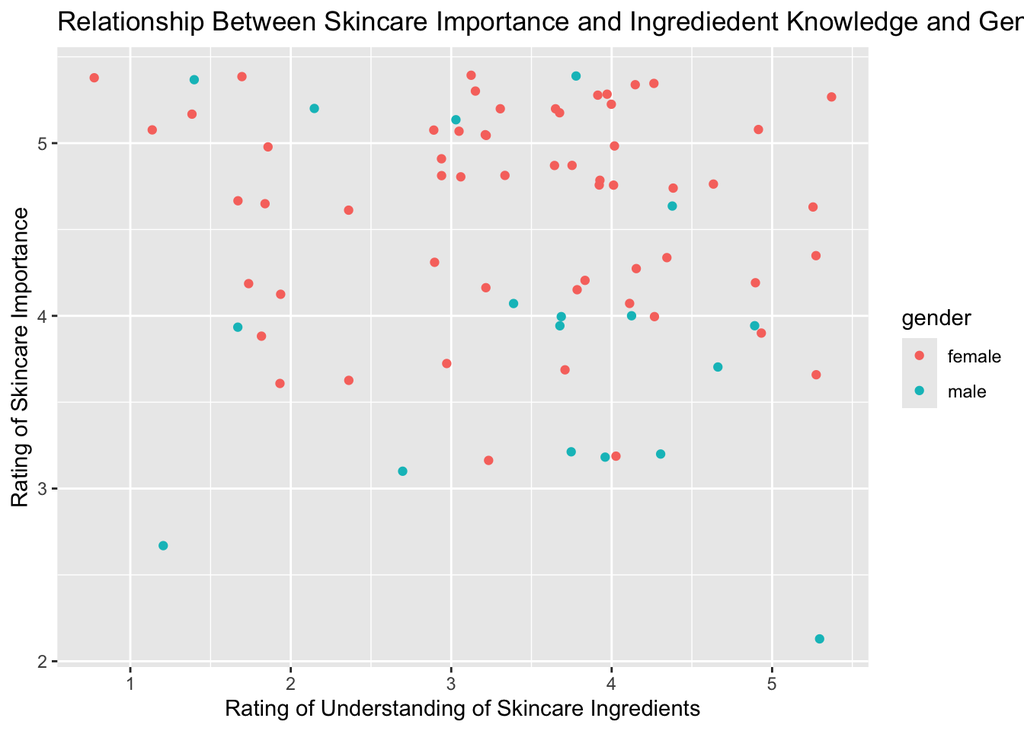

Figure 7

The plot challenges gender stereotypes, as both men and women show diverse attitudes across the full range of skincare importance ratings. The relationship between ingredient knowledge and importance also appears consistent across genders.

Given that male respondents are distributed throughout the plot, including at high levels of both metrics, this plot contradicts assumptions about men being universally less interested in skincare.

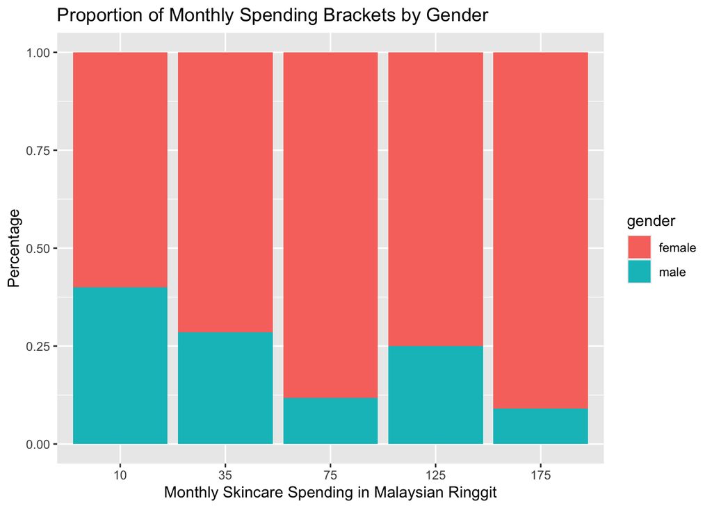

Figure 8

## Correlation analysis

A skincare correlation matrix has been created to more clearly see the relationships between all numerical variables at once. By visualizing these relationships, patterns and trends can be identified, fostering a better understanding of how variables impact one another, fueling further exploration and guiding sections of this report.

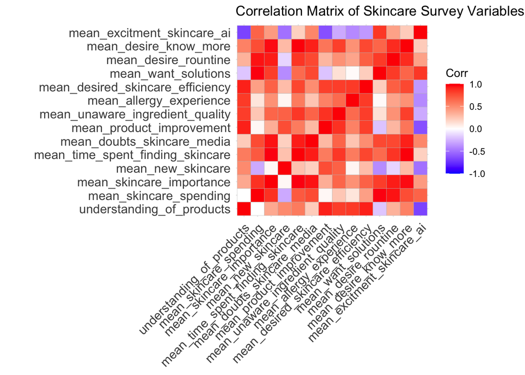

Figure 9

A lot of these correlations in Figure 9 are fairly intuitive. For example, mean_skincare_importance and mean_skincare_spending show a strong positive correlation, which makes sense as those who value skincare are likely to spend more to ensure they are getting the highest quality products and/or are constantly buying new products to try. Similarly, mean_allergy_experience positively correlates with mean_doubts_skincare_media. This suggests that individuals who have experienced allergy-related issues with skincare may be more likely to distrust media claims about products.

## Use of AI

This analysis utilized AI, specifically ChatGPT-4 and ChatGPT-3, for problem-solving, as well as for spelling and grammar checks. Text was frequently input into ChatGPT to review and correct spelling and grammar. On a few occasions, code was also input into ChatGPT for debugging; however, the platform did not prove to be particularly helpful in this regard, producing overly complicated solutions using unfamiliar functions and arguments.

## Summary of progress

I initially anticipated engaging in more coding for Memo 2, as I believed the data to be relatively clean. However, upon attempting to work with the data, I found that it was incredibly messy, particularly with the column names, and I noticed there was no codebook. This resulted in me doing a lot of additional work that I hadn’t anticipated. Even after individually altering every column name, correcting various variables (in terms of syntax and datatype), and creating a codebook from scratch, I was still able to include good univariate analysis. As a result, I believe good progress was made on this memo, as my data is now usable, and I am very familiar with the variables (having read and renamed each one according to its original purpose). So far, I have completed univariate analysis of the sample and have begun analysis aimed at evaluating gender stereotypes around skincare, alongside creating a correlation matrix of the numerical variables.

## Next steps

I plan to undertake more complex data analysis, as my univariate analysis is relatively complete. This will involve more bivariate and multivariate exploration. I aim to dedicate a significant portion of this assignment to exploring the string variables skin_type and motivations, which consist of lists provided by respondents. For instance, I plan to extract specific skin types and potentially create dummy variables to indicate whether someone has, for example, oily skin or dark spots (potentially expanding the dataset). This could allow me to identify relationships between individual skin types and other factors, such as skincare concerns, cultural identities, or allergies.

Since the data did not come with an initial codebook, I will need to manually scan the dataset to identify the full range of possible answers for skin_type, which will be a time-consuming process. For the motivations column, I plan to use string functions to identify patterns and similarities in respondents’ answers.

Additionally, I want to create a dedicated section in this report to analyze perceptions and use of AI in skincare. I also intend to spend more time examining the correlation matrix to uncover interesting findings and ensure these insights are presented in a way that feels relevant and important to the overall report.